# Practicing for the Wrong Apocalypse

Author

Innocent Macherechedze

```r
library(tidyverse)
library(readr)
library(gt)
horror <- read_csv("horror_movies.csv")
```

# Introduction

While horror film is traditionally viewed as escapism, recent psychological research suggests that it serves as a “low-cost simulation” of danger. Scrivner et al. (2021)[^1] argue that these fictional experiences allow audiences to rehearse emotional responses and gather information about threats they have never encountered. This “simulation” theory is supported by empirical evidence from the COVID-19 pandemic, where fans of “prepper” genres such as apocalyptic films exhibited measurably greater psychological resilience and preparedness than non-fans.

If this is true, we need to ask whether the threats horror simulates are the right ones to prepare us for the most likely scenerios. Using the horror film dataset, we will attempt to map the threat landscape the industry has constructed and compares it against scientific estimates of which catastrophic scenarios pose the greatest real-world risk.[^2]

# What is the industry simulating

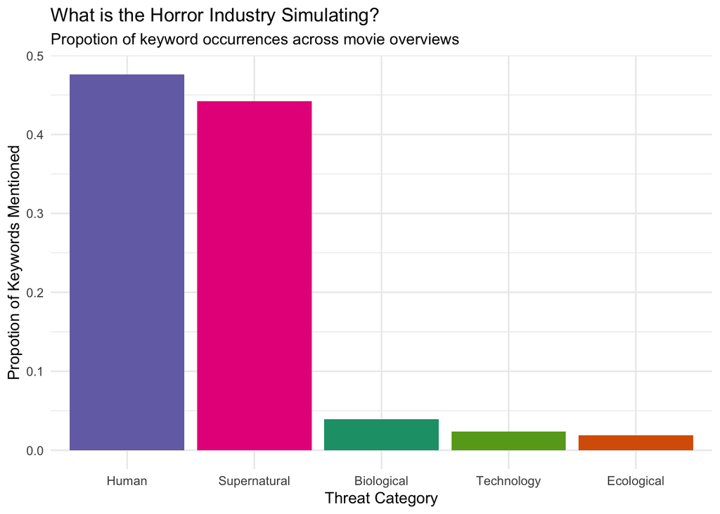

```r
horror_filtered <- horror |>
  filter(original_language == "en") |>
  mutate(
    overview_lower = str_to_lower(overview),
    bio_words = str_count(overview_lower,
                          "(virus|pandemic|outbreak|infection|disease)"),
    tech_words = str_count(overview_lower,
                           "(robot|artificial intelligence|internet|cyber|machine)"),
    eco_words = str_count(overview_lower,
                          "(climate|disaster|ecosystem|nature|weather|volcano)"),
    human_words = str_count(overview_lower,
                             "(killer|slasher|psychopath|murder|war|nuclear)"),
    super_words = str_count(overview_lower,
                            "(ghost|demon|spirit|haunted|curse|zombie|monster)"))

threat_totals <- horror_filtered |>
  summarise(
    Biological = sum(bio_words, na.rm = TRUE),
    Technology = sum(tech_words, na.rm = TRUE),
    Ecological = sum(eco_words, na.rm = TRUE),
    Human = sum(human_words, na.rm = TRUE),
    Supernatural = sum(super_words, na.rm = TRUE)) |>

  pivot_longer(
    cols = 1:5,
    names_to = "threat_category",
    values_to = "total_word_count") |>
  mutate(category_prop = total_word_count/sum(total_word_count))

ggplot (threat_totals, aes(x= fct_reorder(threat_category, total_word_count, .desc = T),
                           y= category_prop,
                           fill = threat_category)) +
  geom_col(show.legend = FALSE) +
  labs(
    title = "What is the Horror Industry Simulating?",
    subtitle = "Propotion of keyword occurrences across movie overviews",
    x = "Threat Category",
    y = "Propotion of Keywords Mentioned")+
  theme_minimal()+
  scale_fill_brewer(palette = "Dark2")
```

If horror films serve as low-cost simulations for survival, the data reveals exactly what we are practicing for. With human and supernatural themes comprising over 90% of the recognized threats, it is clear that the industry’s simulations are heavily biased toward tangible, individualized antagonists rather than systemic or environmental dangers. The next question should therefore be what should be be practicing for. To answer this, I looked at the existential risk estimates compiled by Oxford philosopher Toby Ord, which quantify the actual mathematical probability of what scenarios could bring about human extinction over the next century.

# The Sumulation Gap

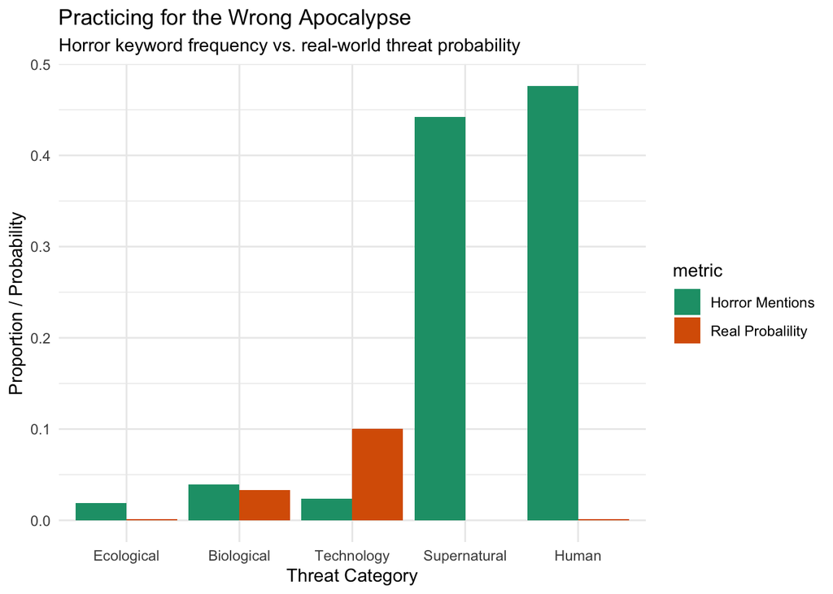

```r
real_world_data <- tibble(
  threat_category = c("Technology", "Biological", "Human", "Ecological", "Supernatural"),
  actual_probability = c(0.10, 0.033, 0.001, 0.001, 0))

threat_totals |>
  left_join(real_world_data, by = "threat_category") |>
  select(threat_category,
         `Horror Mentions` = category_prop,
         `Real Probalility`= actual_probability) |>
  pivot_longer(
    cols = c(`Horror Mentions`, `Real Probalility`),
    names_to = "metric",
    values_to = "value") |>

ggplot(aes(x = fct_reorder(threat_category, value), y = value, fill= metric))+
  geom_col(position = "dodge") +
  labs(
    title = "Practicing for the Wrong Apocalypse",
    subtitle = "Horror keyword frequency vs. real-world threat probability",
    x = "Threat Category",
    y = "Proportion / Probability") +
  theme_minimal()+
  scale_fill_brewer( palette = "Dark2")
```

This chart crystallizes the simulation gap by revealing an inverse relationship. The threats dominating horror cinema (Human and Supernatural) carry negligible real-world probabilities, while the most severe scientific risk (Technology, at 10%) receives a fraction of the cinematic focus (2.4%). The horror genre, it appears, is preparing fans for the wrong apocalypse.

# Do the audience drive the gap?

```r
horror_filtered |>
  filter(!is.na(vote_average), vote_count > 0) |>
  select(vote_average,
         Biological   = bio_words,
         Technology   = tech_words,
         Ecological   = eco_words,
         Human        = human_words,
         Supernatural = super_words) |>
  pivot_longer(cols      = c(Biological, Technology, Ecological, Human, Supernatural),
    names_to  = "threat_category",
    values_to = "word_count") |>
  filter(word_count > 0) |>
  summarise(avg_rating = mean(vote_average, na.rm = TRUE),
            .by= threat_category) |>
  arrange(desc(avg_rating)) |>
  gt() |>
  tab_header(
    title    = "Audience reception by threat category",
    subtitle = "Average ratings for simulated threats") |>
  cols_label(threat_category = "Threat category",
             avg_rating      = "Average rating (1–10)") |>
  fmt_number(columns  = avg_rating,
             decimals = 2)
```

Audience reception by threat category

Average ratings for simulated threats

| Threat category | Average rating (1–10) |
| --- | --- |
| Ecological | 5.12 |
| Supernatural | 4.91 |
| Biological | 4.88 |
| Technology | 4.86 |
| Human | 4.80 |

## Footnotes

[^1]: [Scrivner et al. (2021)](https://pmc.ncbi.nlm.nih.gov/articles/PMC7492010/)
[^2]: [Ord, T. (2025). The Precipice Revisited.](https://www.tobyord.com/writing/the-precipice-revisited)